# AusBus 2016 Vuelta Recap

19 August 2017

### Introduction

With the 2017 Vuelta a España set to commence wheels rolling tonight, it’s perhaps a good time to reflect on our performance twelve months earlier.

| Rider | Times Selected |
| --- | --- |
| Johan Esteban Chaves | 6 |
| Christopher Froome | 4 |
| Alberto Contador | 3 |
| Alejandro Valverde | 3 |
| Daniele Bennati | 3 |
| Louis Meintjes | 3 |
| Nairo Quintana | 3 |
| Simon Gerrans | 3 |
| Tejay Van Garderen | 3 |
| Thomas De Gendt | 3 |
| Davide Formolo | 2 |
| Jean-Pierre Drucker | 2 |

The most popular rider was Columbian Johan Esteban Chaves with 6 of us selecting the always smiling Orica team member to do battle on Spanish roads.

### Top Ten Riders

But of course, picking riders on reputation and past performance was no guarantee of success in the last of the year’s Grand Tours. The top ten highest scoring riders for the Vuelta, in order were:

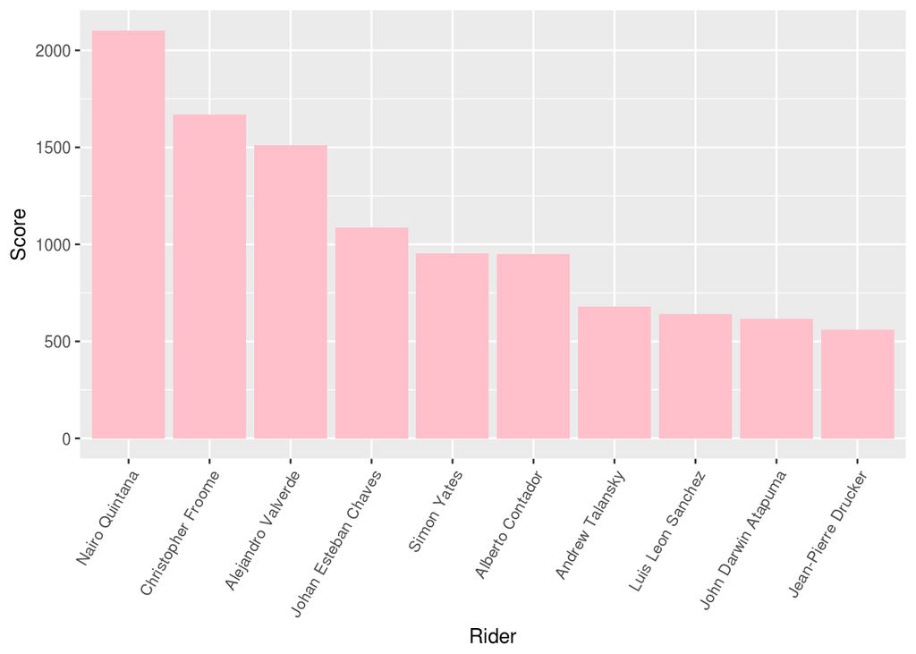

It’s interesting to see that while Contador finished just off the podium in fourth place, he was a bit of a grey-man through the stages and didn’t actually acrue a lot of Velocredits or even finish in the top ten riders based on ROI. Speaking of which…

The top ten highest scoring riders for the Vuelta, based on Return on Investment were:

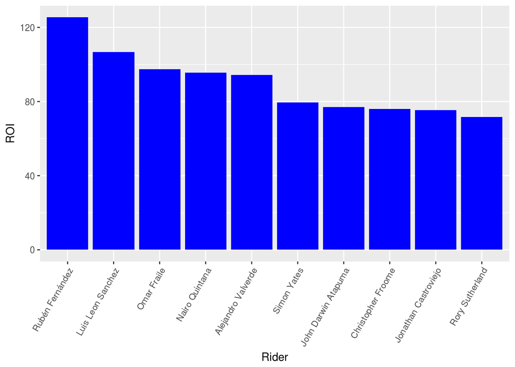

The ROI data is insightful in that it reveals which riders provided the best bang for buck. Although expensive picks such as Quintana ultimately proved good investments, teams backing Ruben Fernandez must have been cheering all the way to the Velocredit bank!

### Overall Team Performance

At the end of a tightly fought three week battle Steve’s safety first helmets took top step on the podium by a comfortable margin over Billy’s squad.

| Team | Directeur | Total |
| --- | --- | --- |
| team helmet | Steve H | 5580 |
| Team Skylark | William Brown | 5156 |
| Big Men in Lycra | Big Matt | 4868 |
| Tiger Power | Ian Cunningham | 4781 |
| Johns and Froome | Alex | 4648 |
| Brake Rub Regression | Simon Lyons | 4431 |
| use rule #5 | Athol Underwood | 4423 |
| Bail`s Bunch | Terry Bailey | 3933 |
| Team Freewheel | Dave Hazzard | 3800 |

### Individual Stage Performance

Steve’s team emerged in a controlling fashion from about Stage 7 and didn’t look like relinquishing the lead for the remainder of the race.

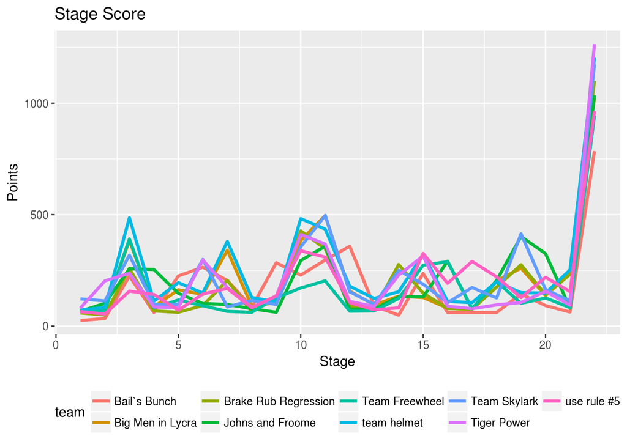

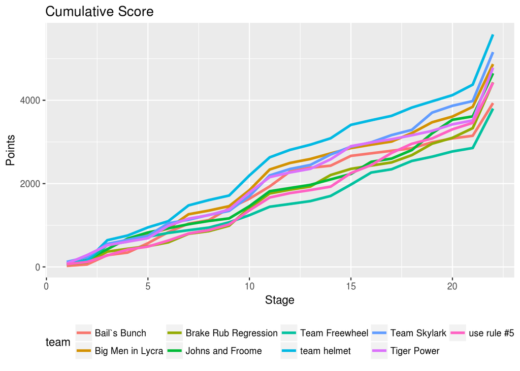

Steve’s selection of big scoring Quintana and Valverde were differentiators for his squad.

| Team | Rider | Rider Total |
| --- | --- | --- |
| Big Men in Lycra | Christopher Froome | 1670 |
| Big Men in Lycra | Alejandro Valverde | 1510 |
| Big Men in Lycra | Johan Esteban Chaves | 1088 |
| Big Men in Lycra | Daniele Bennati | 405 |
| team helmet | Nairo Quintana | 2103 |
| team helmet | Alejandro Valverde | 1510 |
| team helmet | Andrew Talansky | 681 |
| team helmet | Rubén Fernández | 502 |
| Team Skylark | Christopher Froome | 1670 |
| Team Skylark | Johan Esteban Chaves | 1088 |
| Team Skylark | Simon Yates | 953 |
| Team Skylark | Jonathan Castroviejo | 452 |

| Team | Rider | Rider Total |
| --- | --- | --- |
| Bail`s Bunch | Alejandro Valverde | 1510 |
| Bail`s Bunch | Alberto Contador | 950 |
| Bail`s Bunch | Luis Leon Sanchez | 641 |
| Bail`s Bunch | Davide Formolo | 446 |
| Brake Rub Regression | Christopher Froome | 1670 |
| Brake Rub Regression | Johan Esteban Chaves | 1088 |
| Brake Rub Regression | Daniele Bennati | 405 |
| Brake Rub Regression | Omar Fraile | 390 |
| Team Freewheel | Johan Esteban Chaves | 1088 |
| Team Freewheel | Alberto Contador | 950 |
| Team Freewheel | Jean-Pierre Drucker | 560 |
| Team Freewheel | Alexandre Geniez | 486 |

Perhaps there’s some lessons in there as you look to finalise your squads for this year’s Vuelta Get your team in before the cutoff early this evening!